# Unit 3 Project

Ivan Romero

2026-02-26

# Part I: Morphological Data

```r
library(dplyr)
```

```r
library(ggplot2)
library(GGally)
library(MASS)
str(iris)
```

```
## 'data.frame':    150 obs. of  5 variables:
##  $ Sepal.Length: num  5.1 4.9 4.7 4.6 5 5.4 4.6 5 4.4 4.9 ...
##  $ Sepal.Width : num  3.5 3 3.2 3.1 3.6 3.9 3.4 3.4 2.9 3.1 ...
##  $ Petal.Length: num  1.4 1.4 1.3 1.5 1.4 1.7 1.4 1.5 1.4 1.5 ...
##  $ Petal.Width : num  0.2 0.2 0.2 0.2 0.2 0.4 0.3 0.2 0.2 0.1 ...
##  $ Species     : Factor w/ 3 levels "setosa","versicolor",..: 1 1 1 1 1 1 1 1 1 1 ...
```

```r
head(iris)
```

```
##   Sepal.Length Sepal.Width Petal.Length Petal.Width Species
## 1          5.1         3.5          1.4         0.2  setosa
## 2          4.9         3.0          1.4         0.2  setosa
## 3          4.7         3.2          1.3         0.2  setosa
## 4          4.6         3.1          1.5         0.2  setosa
## 5          5.0         3.6          1.4         0.2  setosa
## 6          5.4         3.9          1.7         0.4  setosa
```

```r
summary(iris)
```

```
##   Sepal.Length    Sepal.Width     Petal.Length    Petal.Width
##  Min.   :4.300   Min.   :2.000   Min.   :1.000   Min.   :0.100
##  1st Qu.:5.100   1st Qu.:2.800   1st Qu.:1.600   1st Qu.:0.300
##  Median :5.800   Median :3.000   Median :4.350   Median :1.300
##  Mean   :5.843   Mean   :3.057   Mean   :3.758   Mean   :1.199
##  3rd Qu.:6.400   3rd Qu.:3.300   3rd Qu.:5.100   3rd Qu.:1.800
##  Max.   :7.900   Max.   :4.400   Max.   :6.900   Max.   :2.500
##        Species
##  setosa    :50
##  versicolor:50
##  virginica :50
##
##
##
```

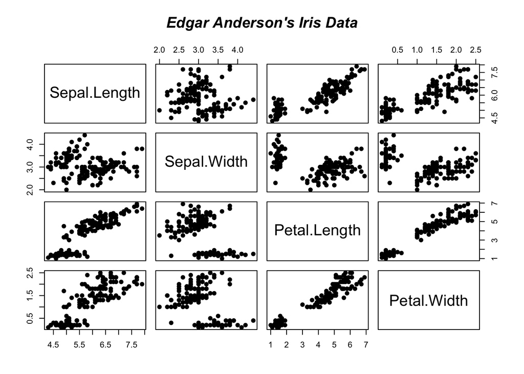

```r
pairs(iris[1:4], main="Edgar Anderson's Iris Data", font.main=4, pch=19)
```

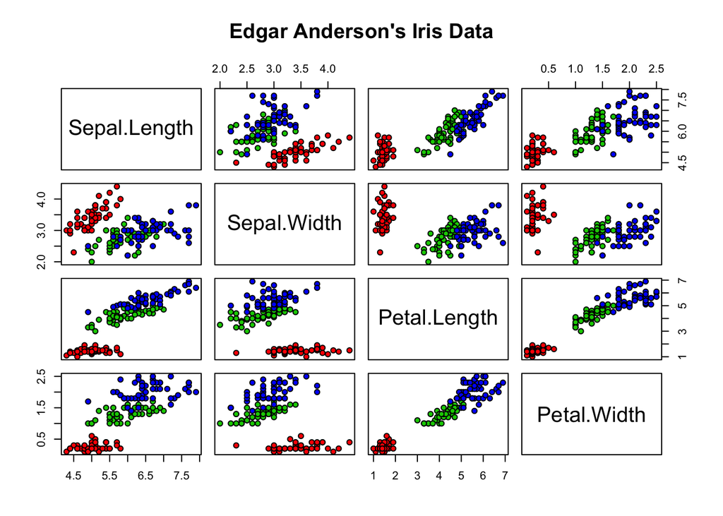

```r
pairs(iris[1:4], main="Edgar Anderson's Iris Data", pch=21, bg=c("red","green3","blue")[unclass(iris$Species)])
```

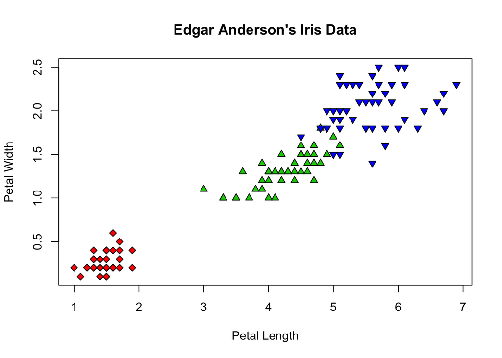

```r
plot(iris$Petal.Length, iris$Petal.Width, pch=c(23,24,25)[unclass(iris$Species)], bg=c("red","green3","blue")[unclass(iris$Species)], main="Edgar Anderson's Iris Data", xlab="Petal Length", ylab="Petal Width")
```

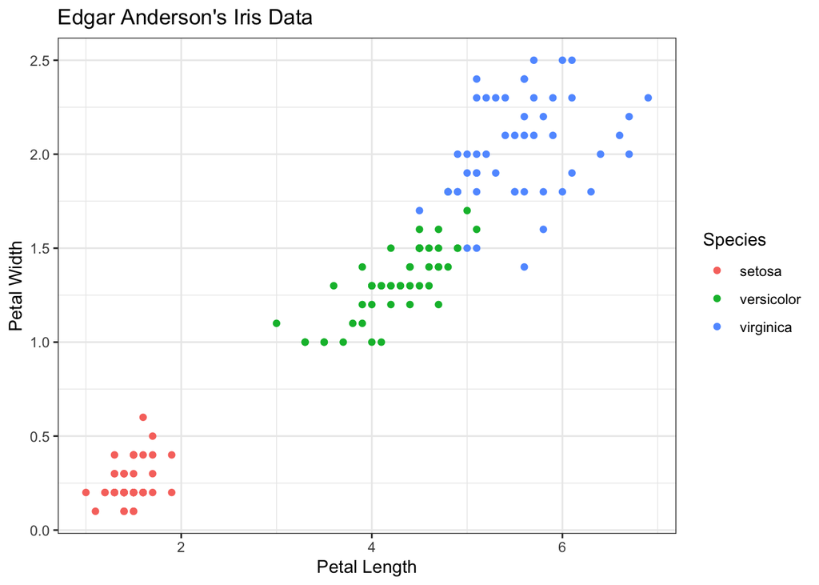

```r
library(ggplot2)
ggplot(iris, aes(x=Petal.Length, y=Petal.Width, color=Species)) + geom_point() + labs(title="Edgar Anderson's Iris Data", x="Petal Length", y="Petal Width") + theme_bw()
```

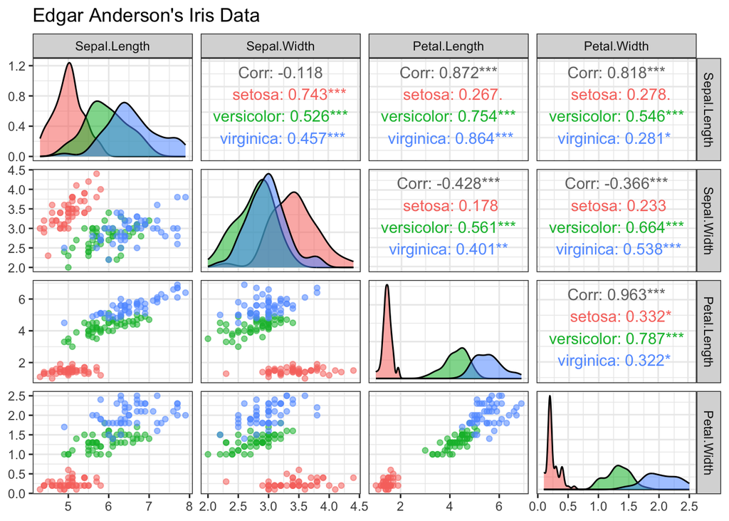

```r
library(GGally)
ggpairs(iris, columns=1:4, aes(color=Species, alpha=0.5)) + labs(title="Edgar Anderson's Iris Data") + theme_bw()
```

```r
library(MASS)
data <- iris %>% dplyr::select(Sepal.Length:Petal.Width)
group <- iris %>% pull(Species)

fit <- lda(data, group)
pred.fit <- predict(fit, iris[1:4])
predictions <- pred.fit$class

iris.table <- table(iris$Species, pred.fit$class)
iris.table
```

```
##
##              setosa versicolor virginica
##   setosa         50          0         0
##   versicolor      0         48         2
##   virginica       0          1        49
```

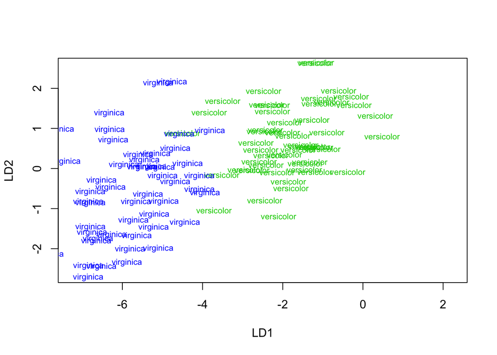

```r
new.iris <- data.frame(Species = iris$Species,
                       predictions = predictions)

plot(fit, col=c("red","green3","blue")[unclass(new.iris$Species)], xlim=c(-5,0))
```

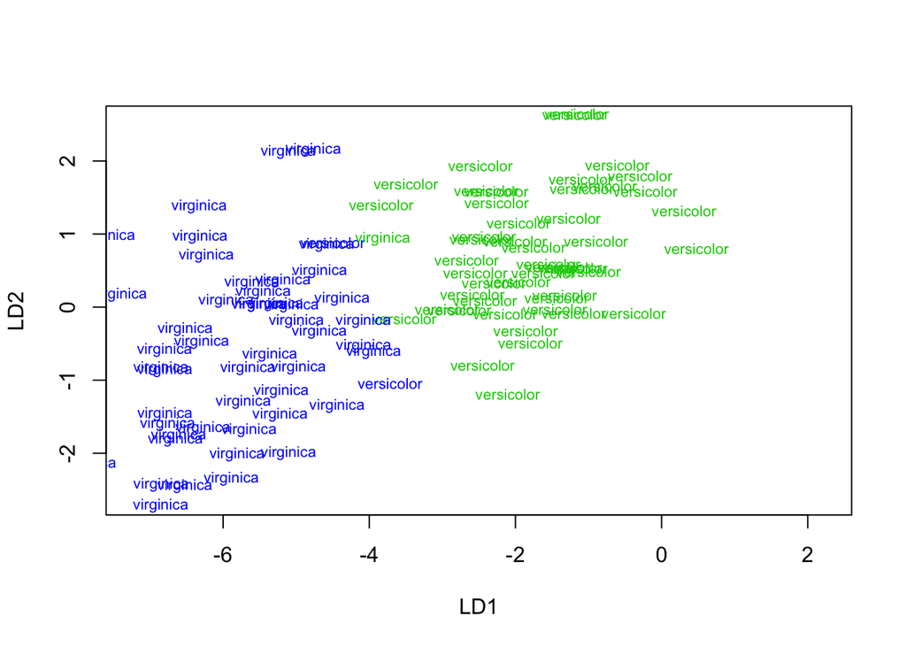

```r
plot(fit, col=c("red","green3","blue")[unclass(new.iris$predictions)], xlim=c(-5,0))
```

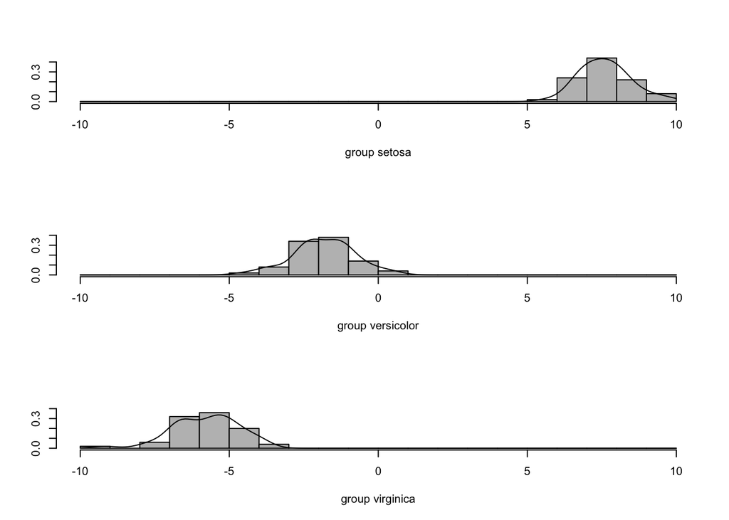

```r
plot(fit, dimen=1, type="both", col="grey")
```

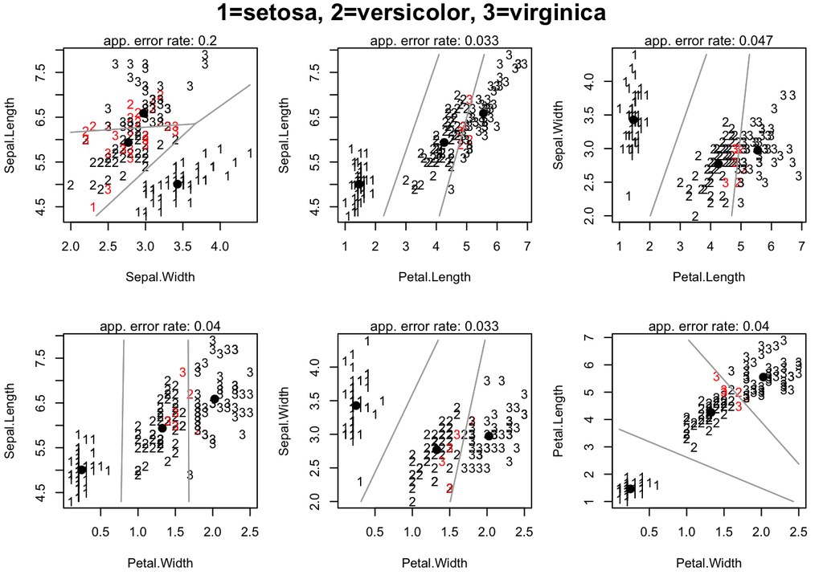

```r
library(klaR)
partimat(iris[1:4], unclass(iris$Species), method="lda", main="1=setosa, 2=versicolor, 3=virginica", imageplot=FALSE)
```

```r
means_table <- iris %>% group_by(Species) %>% summarise(across(Sepal.Length:Petal.Width, mean))
means_table
```

```
## # A tibble: 3 × 5
##   Species    Sepal.Length Sepal.Width Petal.Length Petal.Width
##   <fct>             <dbl>       <dbl>        <dbl>       <dbl>
## 1 setosa             5.01        3.43         1.46       0.246
## 2 versicolor         5.94        2.77         4.26       1.33
## 3 virginica          6.59        2.97         5.55       2.03
```

# Q1: what are the trait means for each species?

# Answer: Setosa has the smallest petal traits on average (petal length ≈ 1.46, petal width ≈ 0.25).

# Versicolor is in the middle (petal length ≈ 4.26, petal width ≈ 1.33).

# Virginica has the largest petal traits (petal length ≈ 5.55, petal width ≈ 2.03).

# Do they seem significantly different?

# Answer: Yes. The petal traits (length and width) separate the species very clearly with little overlap.

# Sepal length and sepal width also differ by species, but there is more overlap, so they are not as distinct